# 6-Mouse-Stroke-Case-Study

Ethan Rogers

07/31/2026

In this vignette we demonstrate the proposed workflow on a case study of mouse brain samples after photothrombotic stroke. These data were obtained from the authors of [Wang et al., 2025](https://doi.org/10.1038/s42255-025-01340-8), “Spatial quantitative metabolomics enables identification of remote and sustained ipsilateral cortical metabolic reprogramming after stroke”. The experimental design is as follows:

- 10 mice received a photothrombotic stroke in the left cortex, below bregma
- Mice were randomly assigned to either a 7 day or a 28 day recovery group
- Tissue was harvested at the recovery timepoint
- Tissue was sprayed with matrix and C-13 labeled yeast extracts
- Tissues were imaged via MALDI at 30 um pixel size
- Yeast extract and matrix were also imaged without tissue, to separate C-13 yeast lipids from endogenous lipids
- LC-MS was then performed on a subset of the brain samples to annotate peaks

Because each sample contains two hemispheres, we can expand the design by adding the non-stroke hemisphere as a within-subject control.

We will test the following hypotheses:

- **Hypothesis A**, *between-subjects*: In stroke-affected tissue, are analytes differentially abundant between the 7 and 28 day recovery conditions?
- **Hypothesis B**, *within-subjects*: In the 28 day condition, are analytes differentially abundant between stroke-affected cortex and non-stroke-affected white matter?

# Step 0: Setup

Please follow the directions in vignette `0-Setup.Rmd` to create the environment and directory trees.

# Step 1: Preprocessing

Preprocessing of the stroke dataset differs substantially from the arthritis case study. First, we will not do peak picking, instead aligning the samples to a list of LC-MS peaks supplied by the authors. Second, we will leverage the multiple yeast internal standards to perform multi-reference normalization.

We will begin by loading packages and data.

```r
library(readr)
library(dplyr)
library(tibble)
library(tidyr)
library(ggplot2)
library(data.table)
library(Cardinal)

source("Utilities.R")
source("SpatialUtilities.R")

# from wd
data.path <- file.path("Mouse-Stroke-Data")
raw.data.path <- file.path(data.path ,"Raw")
preprocessing.data.path <- file.path(data.path ,"Preprocessing-Filtering")
recalib.data.path <- file.path(preprocessing.data.path,"Recalibrated")
aligned.data.path <- file.path(preprocessing.data.path,"Aligned")

outputs.path <- file.path("Outputs")

RNGkind("L'Ecuyer-CMRG")

setCardinalVerbose(verbose = FALSE)
gcinfo(verbose = FALSE)

profile <- "laptop"
hpc <- profile == "hpc"
```

## Load metadata

```r
name_tibble <- read_csv(file.path(outputs.path, "mouse_stroke_metadata.csv"), show_col_types = FALSE)
```

## Load data

We will only load the brain samples.

```r
samp <- name_tibble |>
    filter(!is.na(days) & !is.na(replicate))
```

Recalibration and alignment are by far the longest steps. We only run them when their outputs are not already on disk, so that re-knitting does not repeat them. Delete the relevant directory to force a rerun after changing preprocessing parameters.

```r
run.recalibration <- !all(file.exists(file.path(recalib.data.path,
                                                paste0(samp$short_name, ".imzML"))))

run.alignment <- !all(file.exists(file.path(aligned.data.path,
                                            paste0(samp$short_name, ".imzML"))))

cat("Recalibration:", ifelse(run.recalibration, "running", "reusing existing"), "\n")
```

```
## Recalibration: running
```

```r
cat("Alignment:", ifelse(run.alignment, "running", "reusing existing"), "\n")
```

```
## Alignment: running
```

We will reorient the brains to be vertical and rename the runs for easier file management.

```r
msa.raw <- list()

for (s in samp$filename) {
    m <- readMSIData(file.path(raw.data.path, s))

    # reorient brains to be vertical
    crd <- coord(m)
    if (max(crd$x) - min(crd$x) < max(crd$y) - min(crd$y)) {
        coord(m)$x <- crd$y
        coord(m)$y <- crd$x
    }

    # rename run to be sample short name
    sn <- name_tibble |>
        filter(filename == s) |>
        pull(short_name)

    runNames(m) <- sn
    msa.raw[[sn]] <- m
}

invisible(gc())
```

## Recalibration

These data do not require baseline removal or smoothing, but, like most data, benefit from recalibration. We will recalibrate each sample to a set of reference peaks estimated from that sample.

```r
bp <- SnowfastParam(workers = 10L, force.GC = T)

for (sn in samp$short_name) {
    cat("Starting", sn, "\n")
    est_ref_peaks <- msa.raw[[sn]] |>
        estimateReferencePeaks(chunkopts = list(nchunks = if (hpc) 20L else 60L), BPPARAM = bp)
    msa.raw[[sn]] |>
        recalibrate(ref = est_ref_peaks, tolerance = 10, units = "ppm") |>
        process(chunkopts = list(nchunks = if (hpc) 20L else 60L), BPPARAM = bp) |>
        writeMSIDataSafe(file.path(recalib.data.path, paste0(sn, ".imzML")))
}
```

```
## Starting mouse-28-1
## Starting mouse-28-2
## Starting mouse-28-3
## Starting mouse-28-4
## Starting mouse-28-5
## Starting mouse-7-1
## Starting mouse-7-2
## Starting mouse-7-3
## Starting mouse-7-4
## Starting mouse-7-5
```

```r
rm(msa.raw)
invisible(gc())
```

## Peak alignment from known peak list and IS C13 lipids

As mentioned above, the authors performed LC-MS after MALDI acquisition, which allows for identification of analytes. Their supplemental materials include a list of peaks shared between the LC-MS and MALDI acquisitions, excluding the C-13 yeast analytes. We have supplied it here as `Outputs/LCMSlipids_brain_wang_et_al_nature_metab_2025.csv`. We will skip peak picking and align samples directly to that list, along with 8 yeast extract C-13 internal standard lipids for use in normalization later.

This does mean our analysis inherits the preprocessing decisions made by the authors. For example, the methods and tolerance used to identify peaks shared between the MALDI and LC-MS datasets act as a filter on which peaks are retained. By aligning our dataset to these peaks, our results now rely on the validity of those methods. True reproduction would require us to perform the same analysis from scratch. As reproduction is not the goal of this work, we will use the peaks provided by the authors to accelerate this analysis.

To begin, we will load the peaks and C-13 internal standard lipids from [Wang et al., 2025](https://doi.org/10.1038/s42255-025-01340-8), then combine them into the full set of peaks to align.

```r
lcms.peaks <- read_csv(file.path(outputs.path,
                    "LCMSlipids_brain_wang_et_al_nature_metab_2025.csv"),
                    show_col_types = FALSE)

#for normalization
c13.is.lipids <- c(428.299845, 499.355465, 596.372775, 708.589835, 777.629855, 785.6367, 800.6476, 876.662865)

all.peaks.to.align <- sort(c(c13.is.lipids, lcms.peaks$`Input Mass`))
```

### Measure each sample at the reference peaks

Each sample is measured at the same reference peaks, so we can process them one at a time to keep memory use low.

`peakProcess` with `ref = all.peaks.to.align` does this measurement. These spectra differ from the arthritis data in one important way: they were already centroided, so each spectrum is a list of peaks, not a profile curve. `peakProcess` detects this and does not search for local maxima. Instead, for each reference peak, it takes the centroided peak closest to the reference m/z, as long as it lies within the tolerance, and records its intensity. If no peak lies within the tolerance, the value is zero. No signal-to-noise cutoff is applied, so low intensities are not removed.

We use a tolerance of 6 ppm for every sample. If no tolerance is given, Cardinal estimates one from each sample’s own peak spacing, and for these data it chooses 6 ppm for some samples and 7 ppm for others. A fixed value treats every sample the same way. We do not use the 60 ppm tolerance of the arthritis case study. In these data, neighboring centroided peaks are only about 60 ppm apart, so a 60 ppm window would almost always find some peak, often a different analyte. The two closest reference peaks are 25 ppm apart, more than twice the tolerance, so two reference peaks can never take the same peak.

When `ref` is given, `peakProcess` keeps every reference peak, even rare ones; `filterFreq = FALSE` only makes this explicit. Later steps find the internal standards by their position in `all.peaks.to.align`, so the feature list must match it exactly.

```r
# load, measure at the reference peaks, save
for (sn in samp$short_name) {
    readMSIData(file.path(recalib.data.path, paste0(sn, ".imzML"))) |>
    peakProcess(ref = all.peaks.to.align, tolerance = 6, units = "ppm",
      filterFreq = FALSE) |>
    writeMSIDataSafe(file.path(aligned.data.path, paste0(sn, ".imzML")))
}
invisible(gc())
```

Get the internal standard indices of the aligned data.

```r
ind.c13.is.lipids <- features(readMSIData(file.path(aligned.data.path, paste0(samp$short_name[1], ".imzML"))),
                                mz = c13.is.lipids)
```

Center, combine, and save the aligned images.

```r
# keep everything: the 146 LC-MS lipids plus the 8 C-13 internal standards

mse_list.all <- lapply(samp$short_name, function(short_name){
    m <- readMSIData(file.path(aligned.data.path, paste0(short_name,".imzML")))
    m$x <- m$x - min(m$x) + 1
    m$y <- m$y - min(m$y) + 1
    m
})

mse.all <- Reduce(cbind, mse_list.all)

writeMSIDataSafe(mse.all, file.path(preprocessing.data.path, "Analytes-IS-Aligned.imzML"))
```

Do the same for the analytes alone.

```r
# keep the original 146 lipids, dropping the internal standards

mse_list <- lapply(samp$short_name, function(short_name){
    m <- readMSIData(file.path(aligned.data.path, paste0(short_name,".imzML"))) |>
    subsetFeatures(!(1:length(all.peaks.to.align) %in% ind.c13.is.lipids)) |>
    summarizePixels(stat = c("nnzero", "mean", "sd"), na.rm = T, chunkopts = list(nchunks = 1))
    m$x <- m$x - min(m$x) + 1
    m$y <- m$y - min(m$y) + 1
    m
})

mse <- Reduce(cbind, mse_list)

writeMSIDataSafe(mse, file.path(preprocessing.data.path, "Analytes-Aligned.imzML"))
```

And finally the internal standards alone.

```r
# keep the 8 IS lipids

mse_list.is <- lapply(samp$short_name, function(short_name){
    m <- readMSIData(file.path(aligned.data.path, paste0(short_name,".imzML"))) |>
    subsetFeatures(1:length(all.peaks.to.align) %in% ind.c13.is.lipids) |>
    summarizePixels(stat = c("nnzero", "mean", "sd"), na.rm = T, chunkopts = list(nchunks = 1))
    m$x <- m$x - min(m$x) + 1
    m$y <- m$y - min(m$y) + 1
    m
})

mse.is <- Reduce(cbind, mse_list.is)

writeMSIDataSafe(mse.is, file.path(preprocessing.data.path, "IS-Aligned.imzML"))
```

## ROI selection

In this work we will define two ROIs per sample: the stroke, and a comparable swath of white matter in the opposite hemisphere.

`key` below builds a unique run/x/y string for each pixel, which we use to carry pixel masks between objects that have been subset differently.

```r
key <- function(d) paste(d$run, d$x, d$y, sep = "\r")
```

### Trim background

All MSI samples contain background pixels as well as transitional pixels that bridge the sample edges. Neither background nor transitional pixels contain many sample analytes, but both contain matrix. This combination can substantially increase noise, thus these pixels should be removed. We will do so by using the number of non-zero analytes per pixel as a filter, raising the strictness of the filter near the edges. `add_edge_factor_mse` is a custom function that adds a factor in `pData` denoting pixels that border the edges of the sample, within `r` pixels. Edges are determined by the edges of the coordinate grid. In MALDI, scans are only performed on tissue portions of the acquisition area, thus MS images have irregular edges that roughly follow the tissue area. This is not the case with DESI, thus `add_edge_factor_mse` will not outline tissue in these cases.

We will keep pixels with more than 78 non-zero features in non-edge pixels and more than 88 in edge pixels. These cutoffs were determined by trial and error. Feature mean and standard deviation can also be used to do this, but we chose to stick to number non-zero for simplicity. Finally, `drop_pixel_islands_mask_mse` discards any remaining group of 20 or fewer contiguous pixels.

```r
intensity(mse) <- as.matrix(intensity(mse))

mse <- mse |> add_edge_factor_mse(radius = 10,  contiguous = FALSE)

mse_subset <- mse |>
                subsetPixels(((edge == F & nnzero > 78) | (edge == T & nnzero > 88)))

islands_drop_mask <- drop_pixel_islands_mask_mse(mse_subset, n = 20)

mse_subset_trim_islands <- mse_subset |> subsetPixels(islands_drop_mask)

tissue_mask <- key(pData(mse)) %in% key(pData(mse_subset_trim_islands))
```

### Merge annotations from QuPath

Cardinal has tools for manual ROI segmentation (`selectROI`), but these functions are not well supported by the greater R ecosystem. Additionally, standalone tools purpose-built for annotation, like QuPath, are better suited for drawing complex and overlapping annotations.

To annotate stroke tissue and non-stroke white matter, we used 834.5273 m/z (PS 40:6), as it has been previously [identified as a marker of white matter](https://doi.org/10.1038/s41598-018-37612-5) in a mouse stroke model. We exported this feature as a raster grid image for each sample, loaded the images into QuPath, and drew the annotations there. We then exported the annotations as GeoJSON files and used custom code to transform the QuPath coordinates back to the Cardinal coordinate system. The result is the CSV loaded below, which labels each pixel by stroke ROI, hemisphere, and cortex white matter ROI.

```r
annot.qp <- read_csv(file.path(outputs.path,
                    "stroke-hemisphere-cortexwm-annotations-qupath.csv"),
                    show_col_types = FALSE)
```

```r
annot.idx <- match(key(pData(mse_subset_trim_islands)), key(annot.qp))

stopifnot(!anyNA(annot.idx))

cat("Annotated pixels not in the current trim: ", nrow(annot.qp) - length(annot.idx), "\n")
```

```
## Annotated pixels not in the current trim:  3238
```

```r
pData(mse_subset_trim_islands)$stroke <- annot.qp$stroke[annot.idx]
pData(mse_subset_trim_islands)$hemisphere <- annot.qp$hemisphere[annot.idx]
pData(mse_subset_trim_islands)$cortexwm <- annot.qp$cortexwm[annot.idx]
```

We can visualize them.

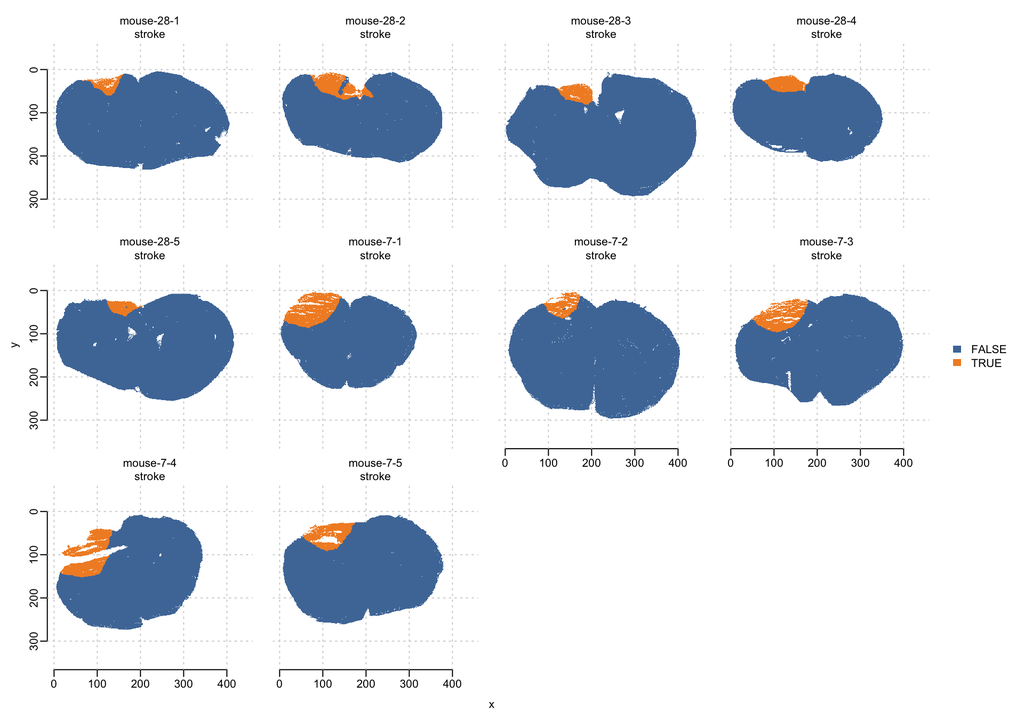

```r
image(mse_subset_trim_islands, "stroke")
```

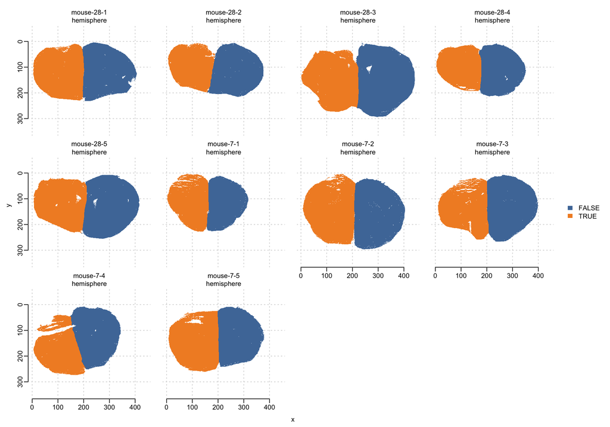

```r
image(mse_subset_trim_islands, "hemisphere")
```

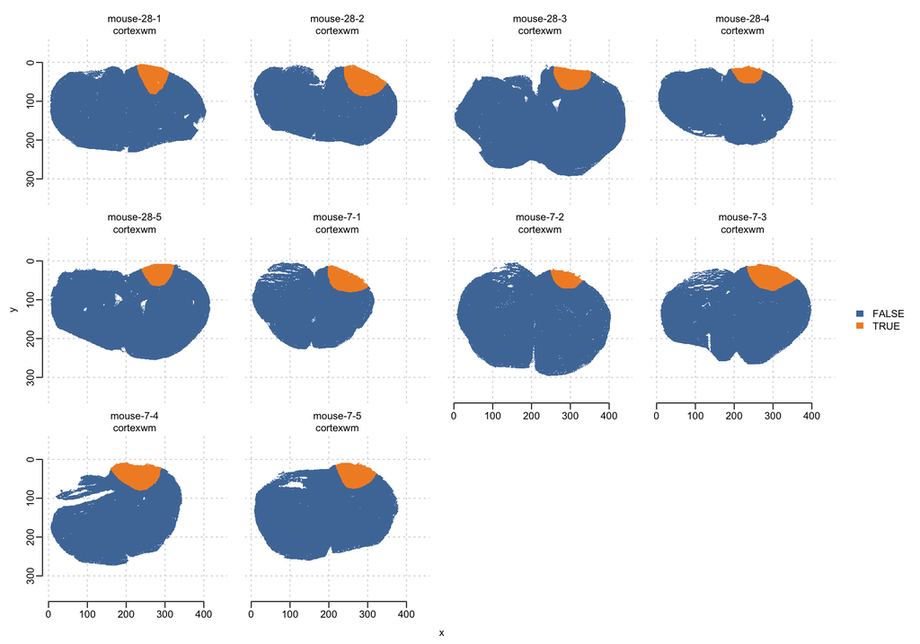

```r
image(mse_subset_trim_islands, "cortexwm")
```

### Why not use single ion segmentation?

Single ion segmentation creates `k` prespecified segments from the spatial distribution of a single ion. With a marker ion that faithfully denotes (either positively or negatively) biological structures of interest, single ion segmentation can be used to programmatically create ROIs without the need for manual segmentation. This process relies heavily on the marker feature being a good marker of the ROI. The white matter marker delineates the stroke tissue well, but areas of healthy white matter are confounded by normal structures of the brain, such as the ventricles. With prior knowledge, we know these structures are different. To an algorithm, they may not be easily separable. Therefore, rather than prototype an algorithmic segmentation process that may yield inconsistent results across tissues, we have done manual segmentation.

### Trim areas with very high internal standard intensity

Matrix and internal standard are sprayed across the entire surface of the sample, thus areas without tissue have minimal ion suppression (from tissue ions) and high ionization efficiency from a high concentration of matrix relative to other ions. Therefore, very high intensity of internal standards is a likely indicator of non-tissue pixels.

Aside from not representing meaningful biology, these areas can bias normalization. We will therefore drop pixels where the mean IS intensity is in the 99th percentile or higher. Some IS features are very low abundance, so we exclude them (mean intensity of 200 or less) from that calculation.

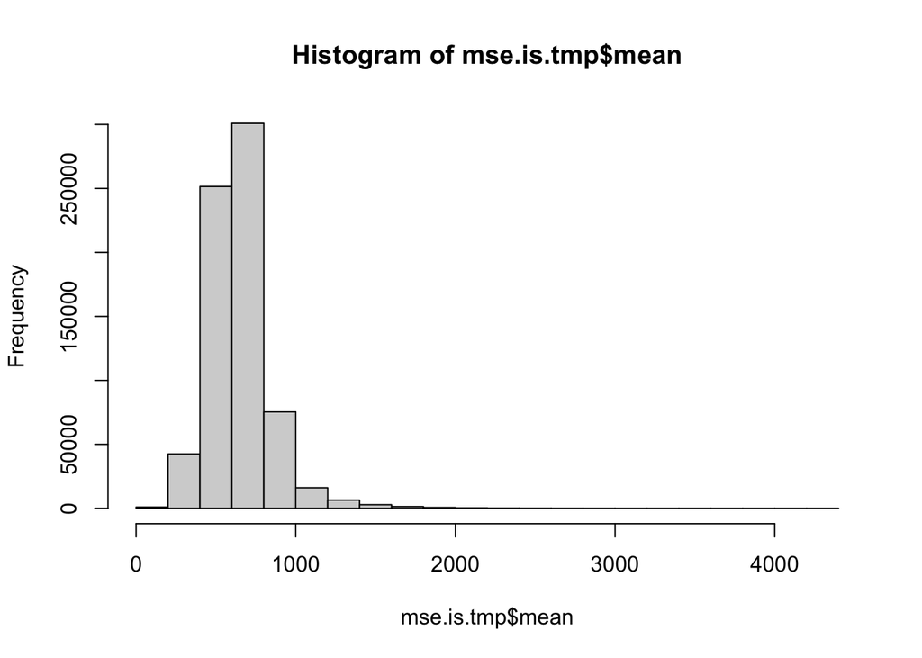

```r
intensity(mse.is) <- as.matrix(intensity(mse.is))

mse.is.tmp <- mse.is |>
    subsetPixels(tissue_mask) |>
    summarizeFeatures(stat = c("nnzero", "sd", "mean"), na.rm = T) |>
    subsetFeatures(mean > 200) |>
    summarizePixels(stat = c("nnzero", "sd", "mean"), na.rm = T)

hist(mse.is.tmp$mean)
```

```r
quantile(mse.is.tmp$mean, p = .99)
```

```
##     99%
## 1332.35
```

```r
is.mask <- mse.is.tmp$mean < quantile(mse.is.tmp$mean, p = .99)
```

Let’s take a look.

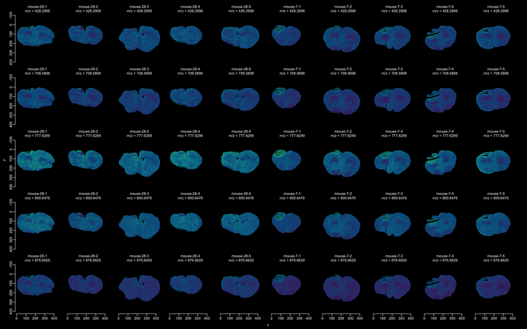

```r
image(mse.is |> subsetPixels(tissue_mask) , subset = is.mask, i = c(1,4,5,7,8), layout = c(5, 10), key = F, grid = F, style = "dark")
```

Now let’s save everything.

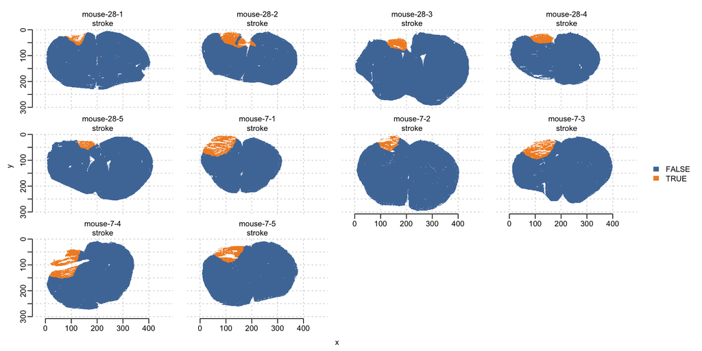

```r
mse.roi.trimmed <- mse_subset_trim_islands |>
    subsetPixels(is.mask)

image(mse.roi.trimmed, "stroke")
```

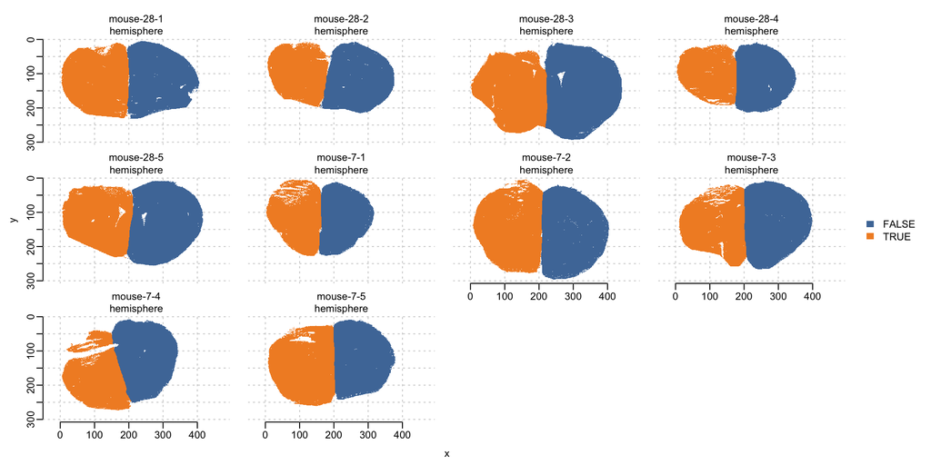

```r
image(mse.roi.trimmed, "hemisphere")
```

```r
writeMSIDataSafe(mse.roi.trimmed, file.path(preprocessing.data.path, "Aligned-Tissue-ROIs.imzML"))
```

```r
mse.is.roi.trimmed <- mse.is |>
    subsetPixels(tissue_mask) |>
    subsetPixels(is.mask)

writeMSIDataSafe(mse.is.roi.trimmed , file.path(preprocessing.data.path, "IS-Aligned-Tissue-ROIS.imzML"))
```

Sanity check.

```r
#final checks
stopifnot(
all(mse.roi.trimmed$run == mse.is.roi.trimmed$run),
all(mse.roi.trimmed$x == mse.is.roi.trimmed$x),
all(mse.roi.trimmed$y == mse.is.roi.trimmed$y)
)
```

## Normalization

As the stroke dataset contains multiple internal standards, we will use reference normalization. To recap, the stroke dataset was sprayed with a mixture of C-13 labeled yeast extracts along with the matrix. The authors then chose 8 C-13 lipids, one from each lipid class, as representative ions for normalization. Theoretically, normalizing each lipid to its class’s representative C-13 IS would correct for ionization efficiency differences specific to each lipid class, which is what the authors did. For simplicity, we will instead normalize analytes to the mean of the high-intensity internal standards.

First, we will load the data and label the IS and marker analytes.

```r
mse.all <- readMSIData(file.path(preprocessing.data.path, "Analytes-IS-Aligned.imzML"))

intensity(mse.all) <- as.matrix(intensity(mse.all))

mask <- key(pData(mse.all)) %in% key(pData(mse.roi.trimmed))

mse.all.trimmed <- mse.all |>
    subsetPixels(mask)

# the ROI labels are copied across positionally, so lets confirm the pixel order
stopifnot(
all(mse.all.trimmed$run == mse.roi.trimmed$run),
all(mse.all.trimmed$x == mse.roi.trimmed$x),
all(mse.all.trimmed$y == mse.roi.trimmed$y)
)

mse.all.trimmed$stroke <- mse.roi.trimmed$stroke
mse.all.trimmed$hemisphere <- mse.roi.trimmed$hemisphere
mse.all.trimmed$cortexwm <- mse.roi.trimmed$cortexwm

# label features
n.features <- nrow(fData(mse.all.trimmed))

fData(mse.all.trimmed)$isIS <- 1:n.features %in% features(mse.all.trimmed, mz=c13.is.lipids)

fData(mse.all.trimmed)$isMarker <- 1:n.features %in% features(mse.all.trimmed, mz=c(834.5273))
```

The custom function below, `normalizeMultipleRefs`, normalizes each spectrum to the mean intensity of multiple references.

```r
normalizeMultipleRefs <- function(object, refs, scale = 1, ...) {
    if ( missing(refs) || is.null(refs) || length(refs) == 0L )
        stop("must provide one or more reference values via 'refs'")
    refs <- sort(unique(as.numeric(refs)))
    FUN <- function(x, t, refs, scale = 1, ...) {
        if ( any(refs < min(t)) || any(refs > max(t)) )
            stop("one or more 'refs' is outside of domain limits")
        i <- matter::bsearch(refs, t, nearest = TRUE)
        b <- mean(x[i], na.rm = TRUE)
        if ( !is.na(b) && b != 0 ) {
            y <- scale * x / b
        } else {
            y <- rep.int(0, length(x))
        }
        dim(y) <- dim(x)
        y
    }
    Cardinal::addProcessing(object, FUN,
        label = "intensity normalization",
        metadata = list(method = "multiref", refs = refs),
        refs = refs, scale = scale, ...)
}
```

Before normalizing, we drop the segmentation marker, so that a feature used to build the ROIs is not carried into analysis, along with the low-intensity internal standards. We then normalize to the mean of the remaining references and rescale for comparability.

```r
#drop features before normalization
prenormalized <- mse.all.trimmed |>
    summarizeFeatures() |>
    subsetFeatures(!isMarker & !(isIS & mean < 200))

normalized <- prenormalized |>
    normalizeMultipleRefs(mz(prenormalized)[fData(prenormalized)$isIS], scale = 1000) |>
    process()
```

Save the dataset.

```r
writeMSIDataSafe(normalized, file.path(preprocessing.data.path, "IS-normalized.imzML"))
```

# Step 2: Filtering and aggregation

Like the arthritis case study, we will perform non-specific filtering on the feature list to drop low quality analytes. Because we aligned the samples to a set of LC-MS derived peaks, we do not have to perform clustering and aggregation; the peak list contains no isotopes.

## Non-specific filtering

First, load the data.

```r
normalized <- readMSIData(file.path(preprocessing.data.path, "IS-normalized.imzML"))

intensity(normalized) = as.matrix(intensity(normalized))
```

Filter out the marker and reference ions.

```r
# isMarker was already dropped before normalization but lets do it anyway
normalized <- normalized |>
            subsetFeatures(!isMarker & !isIS)
```

### Identify low mean and low sd features

We will drop features that are below the 10th percentile in both mean and standard deviation.

```r
normalized <- normalized |>
    summarizeFeatures(stat = c("sd", "nnzero", "mean"), na.rm = T, chunkopts = list(nchunks = 1))

mean.sd.p1 <- normalized |>
    fData() |>
    as_tibble() |>
    mutate(fid = row_number()) |>
    filter(mean < quantile(mean, p = .1) & sd < quantile(sd, p = .1)) |>
    pull(fid) |>
    unique()
```

### Identify features with sparse stroke and/or cortexwm ROI

We will drop features that are non-zero in fewer than 25% of pixels in the stroke or cortex white matter ROI of any run. This will help stabilize the models and mitigate sparsity biasing of ROI means.

```r
normalized.stroke <- normalized |>
    subsetPixels(stroke == T) |>
    summarizeFeatures(stat = c("sd", "nnzero", "mean"), groups = normalized$run[normalized$stroke == T], na.rm = T, chunkopts = list(nchunks = 1))

normalized.cortexwm <- normalized |>
    subsetPixels(cortexwm == T) |>
    summarizeFeatures(stat = c("sd", "nnzero", "mean"), groups = normalized$run[normalized$cortexwm == T], na.rm = T, chunkopts = list(nchunks = 1))
```

Compute the per-run summaries for the stroke ROI.

```r
normalized.stroke.features <- normalized.stroke |>
    fData() |>
    as_tibble() |>
    mutate(fid = row_number()) |>
    dplyr::rename(mean_all = mean, sd_all = sd, nnzero_all = nnzero) |>
    pivot_longer(
        cols = matches("^mouse\\."),
        names_to = c("run", ".value"),
        names_pattern = "(mouse\\.\\d+\\.\\d+)\\.(.*)"
    ) |>
        mutate(run = stringr::str_replace_all(run, "\\.", "-"))

stroke.anyrun.nnzero.lt25 <- normalized.stroke.features |>
    left_join(normalized.stroke |>
        pData() |>
        as_tibble() |>
        group_by(run) |>
        count(),
      by = "run"
    ) |>
    mutate(prop.nnzero = nnzero/n) |>
    group_by(fid) |>
    filter(any(prop.nnzero < .25)) |>
    pull(fid) |>
    unique()
```

And the same for the cortex white matter ROI.

```r
normalized.cortexwm.features <- normalized.cortexwm |>
    fData() |>
    as_tibble() |>
    mutate(fid = row_number()) |>
    dplyr::rename(mean_all = mean, sd_all = sd, nnzero_all = nnzero) |>
    pivot_longer(
        cols = matches("^mouse\\."),
        names_to = c("run", ".value"),
        names_pattern = "(mouse\\.\\d+\\.\\d+)\\.(.*)"
    ) |>
        mutate(run = stringr::str_replace_all(run, "\\.", "-"))

cortexwm.anyrun.nnzero.lt25 <- normalized.cortexwm.features |>
    left_join(normalized.cortexwm |>
        pData() |>
        as_tibble() |>
        group_by(run) |>
        count(),
      by = "run"
    ) |>
    mutate(prop.nnzero = nnzero/n) |>
    group_by(fid) |>
    filter(any(prop.nnzero < .25)) |>
    pull(fid) |>
    unique()
```

Subset out these features.

```r
ind.features.drop <- sort(unique(c(stroke.anyrun.nnzero.lt25, cortexwm.anyrun.nnzero.lt25, mean.sd.p1)))

normalized <- normalized |>
                subsetFeatures(!(1:length(mz(normalized)) %in% ind.features.drop))
```

Save the dataset for modeling.

```r
writeMSIDataSafe(normalized, file.path(preprocessing.data.path, "IS-normalized-filtered.imzML"))
```

Let’s tally what each step dropped.

```r
mse.aligned <- readMSIData(file.path(preprocessing.data.path, "Analytes-IS-Aligned.imzML"))
mse.norm <- readMSIData(file.path(preprocessing.data.path, "IS-normalized.imzML"))
mse.filt <- readMSIData(file.path(preprocessing.data.path, "IS-normalized-filtered.imzML"))

n.aligned <- length(mz(mse.aligned))
n.norm <- length(mz(mse.norm))
n.filt <- length(mz(mse.filt))

cat("Features aligned ", n.aligned, "\n", sep = "")
```

```
## Features aligned 154
```

```r
cat("After dropping the marker and low-intensity internal standards [-",
  n.aligned - n.norm, "] ", n.norm, "\n", sep = "")
```

```
## After dropping the marker and low-intensity internal standards [-4] 150
```

```r
cat("After dropping the remaining internal standards and non-specific filtering [-",
  n.norm - n.filt, "] ", n.filt, "\n", sep = "")
```

```
## After dropping the remaining internal standards and non-specific filtering [-27] 123
```

```r
cat("Pixels aligned ", ncol(mse.aligned), "\n", sep = "")
```

```
## Pixels aligned 746084
```

```r
cat("After background trimming and internal standard masking [-",
  ncol(mse.aligned) - ncol(mse.filt), "] ", ncol(mse.filt), "\n", sep = "")
```

```
## After background trimming and internal standard masking [-53907] 692177
```

```r
cat("In the stroke ROI ", sum(mse.filt$stroke), "\n", sep = "")
```

```
## In the stroke ROI 34320
```

```r
cat("In the cortex white matter ROI ", sum(mse.filt$cortexwm), "\n", sep = "")
```

```
## In the cortex white matter ROI 44327
```

# Step 3: Statistical modeling

We will use essentially the same model as the arthritis case study, specified below:

$$Y_{ijk} = \mu + Subject_{i(j)} + Condition_j + Tissue_k + (Condition
\times Tissue)_{jk} + \epsilon_{ijk} \\
\sum_{j=1}^J Condition_j = 0, \sum_{k=1}^K Tissue_k = 0, \\
\sum_{j=1}^J (Condition \times Tissue)_{jk} = 0, \\ \sum_{k=1}^K
(Condition \times Tissue)_{jk} = 0, \\
Subject_{i(j)} \overset{iid}{\sim}
\mathcal{N}\!\left(0,\sigma^2_{subj}\right),\quad \epsilon_{ijk}
\overset{iid}{\sim} \mathcal{N}\!\left(0,\sigma^2\right)$$

- $Y_{ijk}$: the mean intensity of a feature in the tissue $k$ of subject $i$ from condition $j$
- $Subject_{i(j)}$: the random effect of subject $i$, nested in condition, where $i = 1, \cdots, I$. It is assumed to be independent and Normally distributed around 0 with a variance of $\sigma^2_{subj}$
- $Condition_j$: the fixed effect of condition $j$, where $j = 1, \cdots, J$. In this case, either 7 or 28 days recovery.
- $Tissue_k$: the fixed effect of tissue $k$, where $k = 1, \cdots, K$. In this case, either stroke tissue or non-stroke affected white matter.
- $(Condition \times Tissue)_{jk}$: the fixed effect interaction of condition $j$ and tissue $k$
- $\epsilon_{ijk}$: the random residual error for observation $ijk$, assumed to be independent and Normally distributed around 0 with a variance of $\sigma^2$

There are 10 mice evenly split between conditions. Each sample contributes two tissues, so the final number of observations will be 20, with 5 biological replicates per condition and two observations per subject.

## Subset ROI of interest

To begin, we will load the preprocessed and filtered dataset, then subset only the stroke and cortex white matter ROIs.

```r
modeling.mse <- readMSIData(file.path(preprocessing.data.path, "IS-normalized-filtered.imzML")) |>
    subsetPixels(stroke | cortexwm)
```

## Assign experimental variables

Now we will assign the experimental variables, beginning with day and replicate. To communicate to the modeling software that replicate 1 from day 7 is a different mouse from replicate 1 from day 28, we must assign them different identifiers.

```r
modeling.mse$day <- factor(sub("mouse-(\\d+)-\\d+", "\\1", modeling.mse$run), levels = c(7, 28))

# we need to rename the rep so that the model know mouse 1 from day=7 is a different mouse from mouse 1 day 28

reps <- as.integer(sub("mouse-\\d+-(\\d+)", "\\1", modeling.mse$run))

modeling.mse$subject<- as.factor(ifelse(modeling.mse$day == 28, reps, reps + 5))
```

Let’s do a sanity check that no single pixel is in both the stroke and cortex white matter ROIs.

```r
# confirm no overlaps with cortexwm and stroke, should be False
cat("Any pixels labeled as both cortex white matter AND stroke: ",
    any(modeling.mse$stroke & modeling.mse$cortexwm),
    "\n")
```

```
## Any pixels labeled as both cortex white matter AND stroke:  FALSE
```

Now let’s assign the ROI (tissue) and sample. Sample is the grouping factor that Cardinal will use to compute the mean intensity, our response variable. Here that is the combination of subject and tissue.

```r
# droplevels() so the unobserved "other" level does not enter the model matrix
# as an all-zero column, which makes the fixed effects rank deficient and adds
# non-estimable cells to the emmeans grid
modeling.mse$tissue <- droplevels(
    factor(ifelse(modeling.mse$stroke, "stroke", "cortexwm"),
           levels = c("cortexwm", "stroke", "other")))

modeling.mse$samples <- factor(interaction(modeling.mse$subject, modeling.mse$tissue))
```

## Specify statistical model and fit with meansTest

Now we will fit the models with `meansTest`, using `lmer` so that we can test contrasts later.

```r
mt <- meansTest(modeling.mse, ~ day * tissue, ~ 1|subject, samples = modeling.mse$samples, use_lmer = T, na.rm = T)
```

The `singular` column flags models that could not separate subject variance from residual variance. We will return to these variance estimates in Step 5.

```r
mt
```

```
## MeansTest of length 123
## model: lmerModLmerTest
## DataFrame with 10 rows and 7 columns
##            i        mz                  fixed       random statistic    pvalue
##    <integer> <numeric>            <character>  <character> <numeric> <numeric>
## 1          1   421.271 intensity ~ day + ti.. ~1 | subject        NA        NA
## 2          2   433.235 intensity ~ day + ti.. ~1 | subject        NA        NA
## 3          3   435.250 intensity ~ day + ti.. ~1 | subject        NA        NA
## 4          4   436.283 intensity ~ day + ti.. ~1 | subject        NA        NA
## 5          5   437.266 intensity ~ day + ti.. ~1 | subject        NA        NA
## 6          6   452.277 intensity ~ day + ti.. ~1 | subject        NA        NA
## 7          7   457.234 intensity ~ day + ti.. ~1 | subject        NA        NA
## 8          8   459.248 intensity ~ day + ti.. ~1 | subject        NA        NA
## 9          9   461.267 intensity ~ day + ti.. ~1 | subject        NA        NA
## 10        10   463.282 intensity ~ day + ti.. ~1 | subject        NA        NA
##     singular
##    <logical>
## 1      FALSE
## 2      FALSE
## 3      FALSE
## 4      FALSE
## 5      FALSE
## 6      FALSE
## 7      FALSE
## 8      FALSE
## 9      FALSE
## 10      TRUE
## ... and 113 more results
```

## Visualize diagnostic plots

Before testing, let’s visualize some diagnostic plots. The code below will create the following plots for each feature and save them in `QQ-Itx-SII-Plots-Stroke-TissuexDays`.

1. A **quantile-quantile plot** of residuals
2. An **interaction plot** of mean intensity by day (color) and tissue (x axis)
3. **Single ion images** of each analyte, with the non-ROI areas faded out
4. **Box plots** of residual distributions for each fixed effect - day and tissue

As in `3-Statistical-Modeling`, these plots are used to manually diagnose how well each model meets its assumptions before we test hypotheses.

### QQ plots

```r
qq_plot_frame <- NULL
set.seed(2025)
for (fid in 1:length(mt)) {
  model <- mt[[fid]]
  mf <- model.frame(model)
  sample <- rownames(model.frame(model))
  rownames(mf) <- NULL
  qq_plot_frame <- bind_rows(qq_plot_frame,
                        cbind(tibble(feature_id = fid,
                               residuals = residuals(model),
                               fitted = fitted(model),
                               sample = sample),
                               mf))
}
```

```r
qq_plot_frame <-
  qq_plot_frame |>
  #mutate(feature_id = as.numeric(feature_id)) |>
  left_join(
    tibble(mz = mz(modeling.mse)) |>
      mutate(feature_id = row_number(),
             mz = round(mz, 4)),
    by = join_by("feature_id")
  ) |>
  group_by(mz) |>
  arrange(residuals) |>
  mutate(
    samp = residuals,
    theo = qnorm(ppoints(n()))
  ) |>
  ungroup()

fids <- unique(qq_plot_frame$feature_id)
```

```r
manage_directory("QQ-Itx-SII-Plots-Stroke-TissuexDays")

mse.norm.filt <- readMSIData(file.path(preprocessing.data.path, "IS-normalized-filtered.imzML"))
mse.norm.filt$day <- factor(sub("mouse-(\\d+)-\\d+", "\\1", mse.norm.filt$run), levels = c(7, 28))

# we need to rename the rep so that the model know mouse 1 from day=7 is a different mouse from mouse 1 day 28

reps <- as.integer(sub("mouse-\\d+-(\\d+)", "\\1", mse.norm.filt$run))

mse.norm.filt$subject<- as.factor(ifelse(mse.norm.filt$day == 28, reps, reps + 5))


mse.norm.filt$tissue <- factor(ifelse(mse.norm.filt$stroke, "stroke", ifelse(mse.norm.filt$cortexwm, "cortexwm", "other")),
                            levels = c("cortexwm", "stroke", "other"))

# ---- SII prep (built once); carry full tissue factor for 3-zone alpha ----
pdata_sii <- as.data.table(as.data.frame(pData(mse.norm.filt)))[
  , .(x, y, run, tissue, day)]

run_levels <- c(paste0("mouse-7-", 1:5), paste0("mouse-28-", 1:5))

mz_lookup <- qq_plot_frame |>
  dplyr::distinct(feature_id, mz) |>
  dplyr::arrange(feature_id)

annot_lookup <- lcms.peaks |>
  dplyr::transmute(mz = `Input Mass`, lipid = `LIPID MAPS`) |>
  dplyr::distinct(mz, .keep_all = TRUE)

# Aligned m/z are not guaranteed to be identical to the reference masses they
# were aligned to, so match features back to the LC-MS peak list by nearest m/z
# within a ppm tolerance rather than on rounded equality
match_lipid <- function(query_mz, ppm = 20) {
  vapply(query_mz, function(q) {
    d <- abs(annot_lookup$mz - q) / q * 1e6
    j <- which.min(d)
    if (length(j) == 1L && d[j] <= ppm) annot_lookup$lipid[j] else NA_character_
  }, character(1))
}

# report the match rate so a failed join is loud rather than silently all-NA
cat("Features matched to a LIPID MAPS annotation: ",
    sum(!is.na(match_lipid(mz_lookup$mz))), " of ", nrow(mz_lookup), "\n", sep = "")
```

```
## Features matched to a LIPID MAPS annotation: 123 of 123
```

```r
mz_lookup$fi <- vapply(mz_lookup$mz,
                       function(q) which.min(abs(mz(mse.norm.filt) - q)),
                       integer(1))

sii_intensity <- as.matrix(intensity(mse.norm.filt)[mz_lookup$fi, , drop = FALSE])
rownames(sii_intensity) <- as.character(mz_lookup$feature_id)

cat("Single ion image intensities held in memory: ",
    format(object.size(sii_intensity), units = "auto"), "\n", sep = "")
```

```
## Single ion image intensities held in memory: 649.6 Mb
```

```r
# ---- Panel C: single-ion images; stroke + cortexwm full brightness, other dimmed ----
sii <- function(fid, roi_alpha = 1, other_alpha = 0.3, gray_other = FALSE,
                facet_by_day = FALSE) {
  vals <- as.numeric(sii_intensity[as.character(fid), ])  # one intensity per pixel

  df <- copy(pdata_sii)
  df[, intensity := vals]
  df[, run := factor(run, levels = run_levels)]

  # Default: 2 x 5 (row = day, col = rep). facet_by_day: 5 x 2 (row = rep, col = day).
  facet_layer <- if (facet_by_day) {
    df[, rep := factor(sub("mouse-\\d+-(\\d+)", "\\1", run), levels = 1:5)]
    df[, day := factor(day, levels = c(7, 28))]
    facet_grid(rep ~ day, labeller = labeller(day = ~ paste("Day", .x)))
  } else {
    facet_wrap(~ run, ncol = 5)                           # row1 = day 7, row2 = day 28
  }

  if (gray_other) df[tissue == "other", intensity := NA_real_]  # non-ROI -> gray

  # Colorbar shows only the min and max (intermediate ticks are too cramped).
  rng <- range(df$intensity, na.rm = TRUE)

  common <- list(
    coord_equal(),
    theme_void(),
    facet_layer,
    scale_fill_viridis_c(option = "turbo", na.value = "#bdbdbd",
                         limits = rng, breaks = rng,
                         labels = function(b) format(round(b), big.mark = ",")),
    theme(legend.position = "bottom",
          panel.spacing.x = unit(0, "pt"),
          panel.spacing.y = unit(1, "pt"),
          strip.text.y    = element_blank()),             # no rep row labels
    labs(fill = "Intensity")
  )

  if (gray_other) {
    ggplot(df, aes(x = x, y = -y, fill = intensity)) + geom_raster() + common
  } else {
    df[, alpha_val := fifelse(tissue %in% c("stroke", "cortexwm"),
                              roi_alpha, other_alpha)]
    ggplot(df, aes(x = x, y = -y, fill = intensity)) +
      geom_tile(aes(alpha = alpha_val)) +
      scale_alpha_identity(guide = "none") + common
  }
}

# ---- Panel B: paired intensity across tissue, per-day mean overlay, subject labels ----
itx_fancy <- function(tmp_df) {
  df <- tmp_df |>
    dplyr::mutate(tissue = factor(tissue, levels = c("cortexwm", "stroke")),
                  day    = factor(day, levels = c("7", "28")))

  ggplot(df, aes(x = tissue, y = intensity, group = subject,
                 color = day, fill = day)) +
    ylab("Mean Intensity") +
    xlab(NULL) +
    theme_classic() +
    theme(legend.position = "bottom") +
    stat_summary(aes(group = day, color = day), fun = mean, geom = "point",
                 shape = 21, size = 3.5, fill = "white", stroke = 1.5, alpha = 0.6) +
    stat_summary(aes(group = day, color = day), fun = mean, geom = "line",
                 linewidth = 3.25, alpha = 0.3, lineend = "round") +
    geom_point() +
    geom_line() +
    geom_text_repel(data = df |> dplyr::filter(tissue == "stroke"),
                    aes(label = subject), color = "black",
                    hjust = -0.4, vjust = 0.5, size = 2.5, segment.alpha = 0) +
    labs(color = "Day", fill = "Day")
}
```

```r
library(ggpubr)
library(ggrepel)

for (f in fids) {

  tmp_df <- qq_plot_frame |> filter(feature_id == f)

  # A: QQ of residuals — color = day, shape = tissue
  qqs <- ggplot(tmp_df, aes(theo, samp, shape = tissue, color = day)) +
    geom_point(size = 3, alpha = 0.7) +
    geom_abline(slope = 1, intercept = 0) +
    labs(x = "Theoretical (Normal) Quantiles", y = "Residual Quantiles",
         shape = "Tissue", color = "Day") +
    theme_linedraw() +
    theme(legend.position = "bottom", legend.box = "horizontal") +
    guides(
      color = guide_legend(direction = "vertical", ncol = 1, byrow = TRUE,
                           title.position = "left"),
      shape = guide_legend(direction = "vertical", ncol = 1, byrow = TRUE,
                           title.position = "left")
    ) +
    theme(legend.key.width = unit(0.4, "cm"), legend.spacing.x = unit(0.1, "cm"))

  # D: residuals by each IV (day, tissue)
  var_day <- ggplot(tmp_df, aes(y = day, x = residuals)) +
    geom_boxplot(aes(group = day), outlier.shape = NA, color = "black") +
    geom_point(aes(shape = tissue, color = day), size = 3, alpha = 0.7) +
    labs(x = NULL, y = "Day", shape = "Tissue", color = "Day") +
    theme_linedraw() +
    theme(legend.position = "none",
          axis.text.y = element_text(angle = 90, hjust = 0.5, vjust = 0.5))

  var_tissue <- ggplot(tmp_df, aes(y = tissue, x = residuals)) +
    geom_boxplot(aes(group = tissue), outlier.shape = NA, color = "black") +
    geom_point(aes(shape = tissue, color = day), size = 3, alpha = 0.7) +
    labs(x = NULL, y = "Tissue", shape = "Tissue", color = "Day") +
    theme_linedraw() +
    theme(legend.position = "none",
          axis.text.y = element_text(angle = 90, hjust = 0.5, vjust = 0.5))

  var_boxplots <- ggarrange(var_day, var_tissue, ncol = 2) |>
    annotate_figure(top = "Distribution of residuals by independent variable",
                    bottom = "Residuals",
                    fig.lab = "D", fig.lab.size = 20, fig.lab.face = "bold") +
    theme(panel.border = element_rect(colour = "#999999", fill = NA, linewidth = 0.25))

  qqs <- annotate_figure(
      qqs, top = "Quantile-quantile plots of residuals",
      fig.lab = "A", fig.lab.size = 20, fig.lab.face = "bold") +
    theme(panel.border = element_rect(colour = "#999999", fill = NA, linewidth = 0.25))

  boxps <- annotate_figure(
      itx_fancy(tmp_df), top = "Mean intensity by tissue and day",
      fig.lab = "B", fig.lab.size = 20, fig.lab.face = "bold") +
    theme(panel.border = element_rect(colour = "#999999", fill = NA, linewidth = 0.25))

  sii_plot <- annotate_figure(
      sii(f), top = "Single ion images with stroke ROI highlighted",
      fig.lab = "C", fig.lab.size = 20, fig.lab.face = "bold") +
    theme(panel.border = element_rect(colour = "#999999", fill = NA, linewidth = 0.25))

  # bottom caption: m/z + LIPID MAPS annotation
  this_mz <- unique(tmp_df$mz)[1]
  lipid   <- match_lipid(this_mz)
  cap <- if (is.na(lipid) || lipid == "") {
    paste0("Feature: ", round(this_mz, 3), " m/z")
  } else {
    paste0("Feature: ", round(this_mz, 3), " m/z   |   ", lipid)
  }

  ggarr <- ggarrange(
      ggarrange(qqs, boxps, nrow = 2),
      ggarrange(sii_plot, var_boxplots, nrow = 2, heights = c(5, 3)),
      ncol = 2, widths = c(1, 2)) |>
    annotate_figure(bottom = cap)

  ggsave(file.path("QQ-Itx-SII-Plots-Stroke-TissuexDays", paste0("QQ-", f, ".png")),
         plot = ggarr, height = 9, width = 11, units = "in")

  if (f == fids[1]) first_ggarr <- ggarr
}
```

Let’s take a look at the first one:

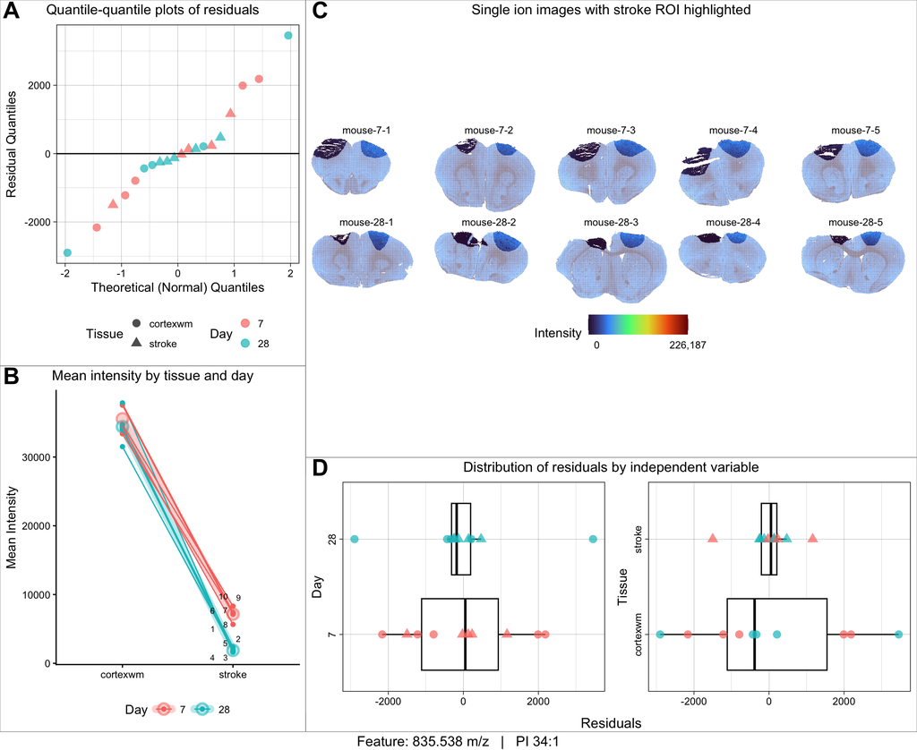

```r
first_ggarr
```

## Restrict to adequately fit models

As in `3-Statistical-Modeling`, we manually classified each feature’s QQ plot, residual variance, and outliers from this plot set, recorded in `Outputs/stroke-feature-model-fit-evaluation.csv`. We test hypotheses only on the features that passed all three.

```r
model_fit_eval <- read_csv(file.path(outputs.path,
                                     "stroke-feature-model-fit-evaluation.csv"),
                           show_col_types = FALSE) |>
  mutate(across(qq:outliers, as.factor))

# guard against the evaluation drifting out of sync with the feature list
stopifnot(nrow(model_fit_eval) == length(mt))

passed <- model_fit_eval |>
  filter(qq == "ok" & var == "ok" & outliers == "ok")

mt <- mt[passed$fid]
```

# Step 4: Statistical inference

With the models fit, we can test our hypotheses. As in `4-Statistical-Inference`, we will run all pairwise contrasts with `contrastTest` and then extract the two of interest.

## Load packages

```r
library(tidyverse)
library(Cardinal)
library(lmerTest)   # provides fixef()/VarCorr() for the reference means & variances
library(ggrepel)    # for labelling the top volcano points
```

First, labels for our two hypotheses. `contrastTest` names each contrast after the levels being compared, so we also record the exact names it emits.

```r
# Hypothesis labels
lab_h1 <- "In stroke: day 7 - day 28"      # between-subject
lab_h2 <- "In day 28: cortexwm - stroke"   # within-subject

# Exact contrast names as emitted by contrastTest
name_h1 <- "day7 stroke - day28 stroke"
name_h2 <- "day28 cortexwm - day28 stroke"
```

Now run the contrasts. As with the arthritis study, this produces every pairwise combination of the four (2x2) levels of day and tissue, of which we only care about two.

```r
# Run all pairwise contrasts
ct <- contrastTest(mt, specs = ~ day * tissue, method = "pairwise")
```

`topFeatures` returns a wide table with FDR-adjusted P values for each contrast, corrected independently.

```r
# Wide results table
tf <- as_tibble(topFeatures(ct))   # returns all features; pass n = to limit
```

The column names of that table are built from the contrast names, so the helper below pulls out a single contrast and strips the prefix back off.

```r
# topFeatures column names are make.names(contrast) + "." + {estimate,pvalue,fdr}.
# Pull one contrast's columns and strip the prefix back to estimate/pvalue/fdr.
pull_contrast <- function(tf, contrast_name, label) {
  prefix <- paste0(make.names(contrast_name), ".")
  if (!any(startsWith(names(tf), prefix)))
    stop("No columns start with '", prefix, "'.\nAvailable: ",
         paste(names(tf), collapse = ", "))
  tf |>
    select(i, mz, starts_with(prefix)) |>
    rename_with(~ str_remove(.x, fixed(prefix)), starts_with(prefix)) |>
    mutate(contrast = label)
}
```

To express each estimate as a percent difference, we need the mean of the reference level of each comparison. We can compute these directly from the fixed effects of each model.

```r
# Reference-level cell means from the fixed effects (reference levels = day7,
# cortexwm), used to express the estimate as a percent difference.
#   day-7 stroke   = (Intercept) + tissuestroke
#   day-28 cortexwm = (Intercept) + day28
ref_means <- bind_rows(lapply(seq_len(length(mt)), function(k) {
  b <- fixef(mt[[k]])
  stopifnot(all(c("(Intercept)", "tissuestroke", "day28") %in% names(b)))
  # after mt[passed$fid], i keeps each model's original feature index, so use it
  # rather than the position k to match the contrast results joined by i
  tibble(i      = mcols(mt)$i[k],
         ref_h1 = unname(b["(Intercept)"] + b["tissuestroke"]),
         ref_h2 = unname(b["(Intercept)"] + b["day28"]))
}))
```

Now we can assemble both hypotheses into one table, attach the percent differences, and label the features with their LIPID MAPS identities.

```r
signift_stroke <- bind_rows(
  pull_contrast(tf, name_h1, lab_h1) |>
    left_join(ref_means |> transmute(i, ref = ref_h1), by = "i"),
  pull_contrast(tf, name_h2, lab_h2) |>
    left_join(ref_means |> transmute(i, ref = ref_h2), by = "i")
) |>
  mutate(pct_delta = estimate / ref,
         signif_after_fdr_adj = fdr < 0.1,      # threshold adjustable
         # panel order: h1 (between-subject, days in stroke) left, h2 (within-subject) right
         contrast = factor(contrast, levels = c(lab_h1, lab_h2))) |>
  arrange(pvalue) |>
  mutate(lipid = match_lipid(mz))
```

## Correct for multiple testing

How many features are significant for each hypothesis at an FDR of 0.1?

```r
signift_stroke |>
  summarize(Count = n(), .by = c(contrast, signif_after_fdr_adj)) |>
  knitr::kable()
```

| contrast | signif_after_fdr_adj | Count |
| --- | --- | --- |
| In day 28: cortexwm - stroke | TRUE | 76 |
| In stroke: day 7 - day 28 | TRUE | 61 |
| In stroke: day 7 - day 28 | FALSE | 24 |
| In day 28: cortexwm - stroke | FALSE | 9 |

Let’s visualize both comparisons as a volcano plot, labeled with the two most significant annotated lipids per hypothesis. As in the arthritis case study, the dashed line marks an unadjusted P value of 0.01.

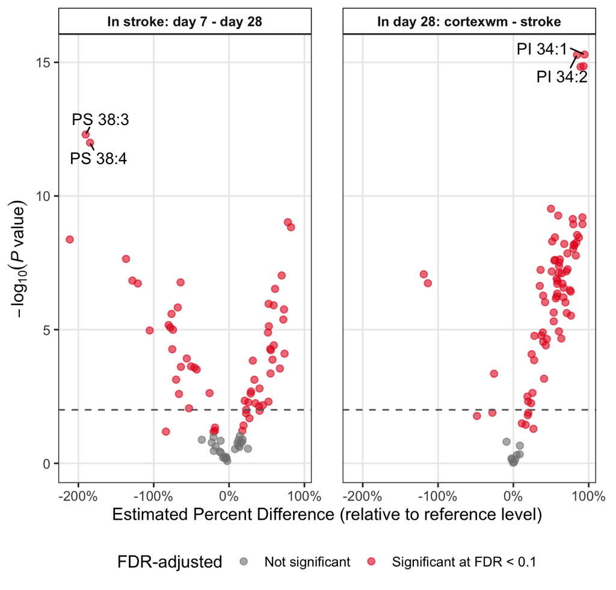

```r
volcano_labels <- signift_stroke |>
  dplyr::filter(!is.na(lipid)) |>
  dplyr::slice_min(pvalue, n = 2, by = contrast)

signift_stroke |>
  ggplot(aes(x = pct_delta, y = -log10(pvalue), color = signif_after_fdr_adj)) +
  geom_point(alpha = 0.6, size = 2) +
  geom_text_repel(data = volcano_labels, aes(label = lipid),
                  color = "black", size = 4, min.segment.length = 0,
                  max.overlaps = Inf, box.padding = 0.4,
                  show.legend = FALSE) +
  geom_hline(yintercept = -log10(0.01), linetype = "dashed", color = "gray40") +
  #geom_vline(xintercept = 0, color = "gray80") +
  facet_wrap(~contrast) +
  scale_x_continuous(labels = scales::percent) +
  scale_color_manual(
    values = c("TRUE" = "#E41A1C", "FALSE" = "gray50"),
    labels = c("TRUE" = "Significant at FDR < 0.1", "FALSE" = "Not significant"),
    name   = "FDR-adjusted"
  ) +
  labs(
    x = "Estimated Percent Difference (relative to reference level)",
    y = expression(-log[10](italic(P)~value))
  ) +
  theme_bw(base_size = 12) +
  theme(
    panel.grid.minor = element_blank(),
    strip.background = element_rect(fill = "white", color = "black"),
    strip.text       = element_text(face = "bold"),
    legend.position  = "bottom",
    panel.spacing.x  = unit(1.5, "lines"),  # keeps edge tick labels of adjacent panels apart
    plot.margin      = margin(5.5, 14, 5.5, 5.5)  # room for the rightmost tick label
  )
```

```r
ggsave(file.path("Recreated-Figures", "Figure-Stroke-Volcano.png"),
       height = 5.75, width = 6, units = "in")
```

Below are the significant features for each hypothesis, with their LIPID MAPS annotations.

```r
signift_stroke |>
  filter(signif_after_fdr_adj) |>
  mutate(`M/Z` = round(mz, 3),
         Lipid = lipid,
         `Percent Difference` = round(pct_delta * 100, 1),
         `P Value` = signif(pvalue, 3),
         `FDR Adj. P Value` = signif(fdr, 3)) |>
  select(Hypothesis = contrast, `M/Z`, Lipid, `Percent Difference`,
         `P Value`, `FDR Adj. P Value`) |>
  arrange(Hypothesis, `P Value`) |>
  kableExtra::kbl() |>
  kableExtra::kable_styling(full_width = FALSE) |>
  kableExtra::scroll_box(width = "100%", height = "400px")
```

| Hypothesis | M/Z | Lipid | Percent Difference | P Value | FDR Adj. P Value |
| --- | --- | --- | --- | --- | --- |
| In stroke: day 7 - day 28 | 812.540 | PS 38:3 | -190.3 | 0.00e+00 | 0.00e+00 |
| In stroke: day 7 - day 28 | 810.528 | PS 38:4 | -184.5 | 0.00e+00 | 0.00e+00 |
| In stroke: day 7 - day 28 | 746.567 | PE 36:0 | 78.1 | 0.00e+00 | 0.00e+00 |
| In stroke: day 7 - day 28 | 790.539 | PE 40:6/PE O-40:7;O | 82.2 | 0.00e+00 | 0.00e+00 |
| In stroke: day 7 - day 28 | 786.530 | PS 36:2 | -211.4 | 0.00e+00 | 1.00e-07 |
| In stroke: day 7 - day 28 | 857.516 | PI 36:4 | -136.7 | 0.00e+00 | 3.00e-07 |
| In stroke: day 7 - day 28 | 464.314 | LPE O-18:1 | 69.9 | 1.00e-07 | 1.10e-06 |
| In stroke: day 7 - day 28 | 814.554 | PS 38:2 | -128.3 | 1.00e-07 | 1.60e-06 |
| In stroke: day 7 - day 28 | 809.519 | PI 32:0 | -64.3 | 2.00e-07 | 1.60e-06 |
| In stroke: day 7 - day 28 | 858.525 | PS 42:8 | -121.1 | 2.00e-07 | 1.60e-06 |
| In stroke: day 7 - day 28 | 745.482 | PA 40:7 | 61.1 | 3.00e-07 | 2.30e-06 |
| In stroke: day 7 - day 28 | 675.492 | PA 34:0 | 52.5 | 1.10e-06 | 7.70e-06 |
| In stroke: day 7 - day 28 | 524.277 | LPE 22:6 | 59.2 | 1.20e-06 | 8.00e-06 |
| In stroke: day 7 - day 28 | 723.496 | PA 38:4 | -68.1 | 1.50e-06 | 9.00e-06 |
| In stroke: day 7 - day 28 | 747.497 | PA 40:6 | 72.9 | 1.80e-06 | 9.90e-06 |
| In stroke: day 7 - day 28 | 887.559 | PI 38:3 | -76.3 | 2.60e-06 | 1.37e-05 |
| In stroke: day 7 - day 28 | 772.584 | PE 38:1 | 72.0 | 4.20e-06 | 2.10e-05 |
| In stroke: day 7 - day 28 | 885.551 | PI 38:4 | -80.2 | 6.70e-06 | 3.19e-05 |
| In stroke: day 7 - day 28 | 718.539 | PE 34:0 | 52.9 | 7.50e-06 | 3.34e-05 |
| In stroke: day 7 - day 28 | 645.449 | PA 32:1 | -78.0 | 8.30e-06 | 3.53e-05 |
| In stroke: day 7 - day 28 | 886.552 | PS 44:8 | -74.5 | 1.01e-05 | 4.08e-05 |
| In stroke: day 7 - day 28 | 760.511 | PS 34:1 | -105.3 | 1.07e-05 | 4.14e-05 |
| In stroke: day 7 - day 28 | 744.554 | PE 36:1 | 51.7 | 1.28e-05 | 4.73e-05 |
| In stroke: day 7 - day 28 | 749.507 | PA 40:5 | 59.4 | 3.86e-05 | 1.37e-04 |
| In stroke: day 7 - day 28 | 709.387 | PG 28:2;O3 | 54.6 | 5.28e-05 | 1.77e-04 |
| In stroke: day 7 - day 28 | 883.534 | PI 38:5 | -75.4 | 5.42e-05 | 1.77e-04 |
| In stroke: day 7 - day 28 | 762.510 | PE 38:6/PE O-38:7;O | 55.5 | 5.85e-05 | 1.84e-04 |
| In stroke: day 7 - day 28 | 835.538 | PI 34:1 | 73.7 | 7.92e-05 | 2.40e-04 |
| In stroke: day 7 - day 28 | 603.289 | PA 26:4;O3 | -56.2 | 1.20e-04 | 3.52e-04 |
| In stroke: day 7 - day 28 | 837.545 | PI 34:0 | 57.7 | 1.33e-04 | 3.76e-04 |

[output cut: 107 more lines]

As before, we can inspect the distributions of unadjusted P values for signs of interdependence between tests.

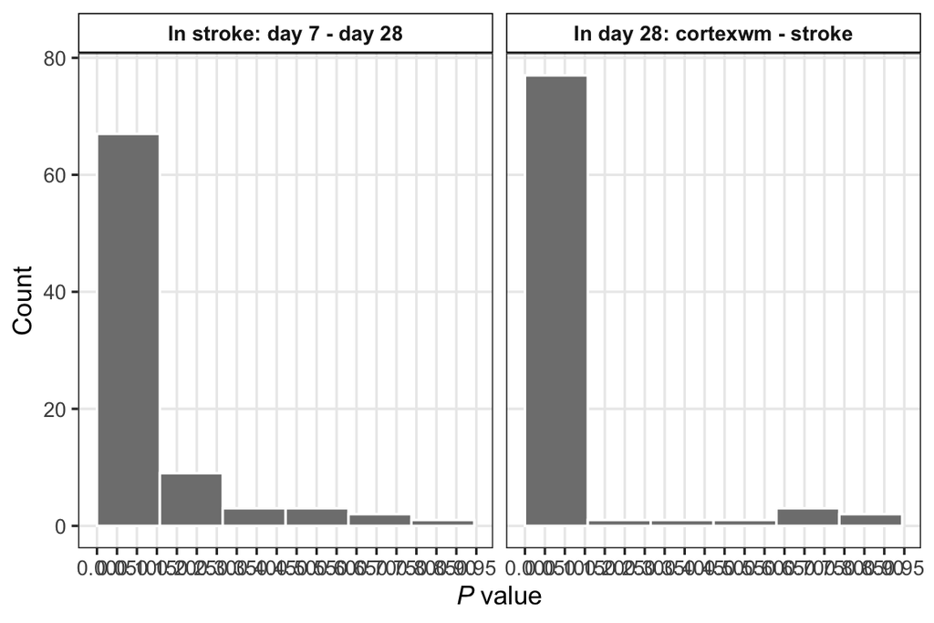

```r
signift_stroke |>
  ggplot(aes(x = pvalue)) +
  geom_histogram(bins = 7, fill = "gray50", color = "white", boundary = 0) +
  facet_wrap(~contrast) +
  scale_x_continuous(breaks = seq(0, 1, by = 0.05)) +
  labs(x = expression(italic(P)~value), y = "Count") +
  theme_bw(base_size = 12) +
  theme(panel.grid.minor = element_blank(),
        strip.background = element_rect(fill = "white", color = "black"),
        strip.text = element_text(face = "bold"))
```

Finally, we will recreate the single ion images of the most significant ion per comparison from the manuscript.

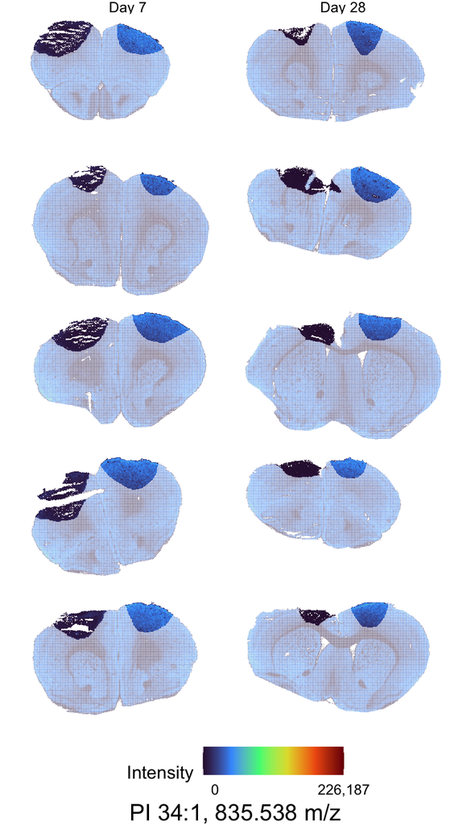

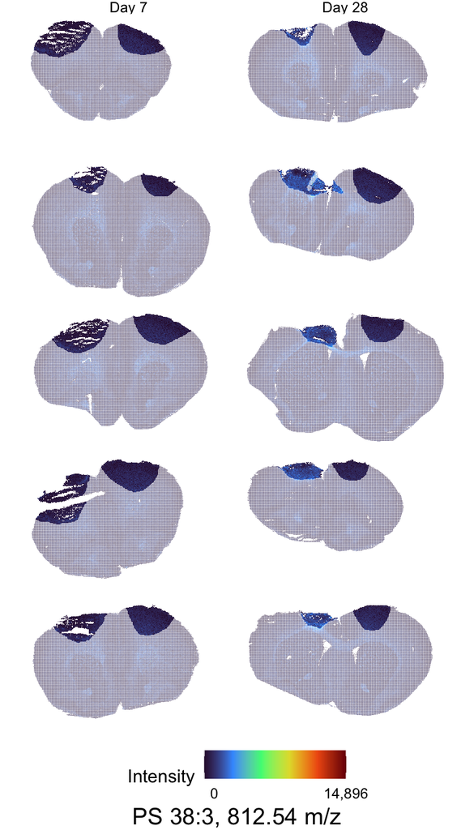

```r
# Most significant ion (smallest p-value) in each contrast.
top_ion_per_contrast <- signift_stroke |>
  dplyr::slice_min(pvalue, n = 1, by = contrast)

for (k in seq_len(nrow(top_ion_per_contrast))) {

  row <- top_ion_per_contrast[k, ]

  fid <- mz_lookup$feature_id[which.min(abs(mz_lookup$mz - row$mz))]

  cap <- if (is.na(row$lipid) || row$lipid == "") {
    paste0("Feature: ", round(row$mz, 3), " m/z")
  } else {
    paste0(row$lipid, ", ", round(row$mz, 3), " m/z")
  }

  sii_plot <- annotate_figure(
      sii(fid, facet_by_day = TRUE),
      bottom = text_grob(cap, size = 14))

  ggsave(file.path("Recreated-Figures",
                   paste0("Figure-Stroke-TopSII-", make.names(row$contrast), ".png")),
         plot = sii_plot, height = 6, width = 3, units = "in")

  print(sii_plot)
}
```

# Step 5: Designing future experiments

Like the arthritis study, we can conclude this investigation by using the estimates of variance for sample size calculations.

First, we will pull the estimates of variance from each model.

```r
df_var <- bind_rows(lapply(seq_len(length(mt)), function(i) {
  m  <- mt[[i]]
  vc <- as.data.frame(VarCorr(m))
  tibble(sigma2_subject  = vc$vcov[1],                 # subject intercept var
         sigma2_residual = attr(VarCorr(m), "sc")^2)   # residual var
}))
```

Then fix the power and target FDR and compute the median variance components.

```r
FDR   <- 0.05
power <- 0.9

median.sigma.subject <- median(df_var$sigma2_subject,  na.rm = TRUE)
median.sigma.error   <- median(df_var$sigma2_residual, na.rm = TRUE)
```

We also need a typical reference mean for each comparison, so that differences on the intensity scale can be expressed as percent differences.

```r
ref_by_comparison <- signift_stroke |>
  group_by(contrast) |>
  summarize(ref = median(ref, na.rm = TRUE), .groups = "drop") |>
  mutate(contrast = as.character(contrast))
```

The sample size calculation is the same normal approximation used in `5-Designing-Future-Experiments`.

```r
calc_sample_size <- function(desired_difference, alpha, power,
                             variance_estimate_without_I) {
  delta   <- seq(desired_difference[1], desired_difference[2], by = 1)
  z_alpha <- qnorm(1 - alpha / 2)
  z_beta  <- qnorm(power)
  aa      <- z_alpha + z_beta
  numSample <- variance_estimate_without_I / (delta / aa)^2
  data.frame(delta, numSample, FDR, power)
}
```

Set reasonable alphas for a couple of multiple-testing scenarios.

```r
alpha_1  <- power * FDR / (1 + (1 - FDR) * 1)    # single comparison
alpha_50 <- power * FDR / (1 + (1 - FDR) * 50)   # FDR, 50% true-negative rate
alpha_90 <- power * FDR / (1 + (1 - FDR) * 90)   # FDR, 90% true-negative rate
```

Compute the variance of each difference. The between-subject comparison (Hypothesis A) carries both subject and residual variation, whereas the within-subject comparison (Hypothesis B) carries only residual variation, as each subject acts as its own control.

```r
var_within  <- 2 * (median.sigma.error)
var_between <- 2 * (median.sigma.error + median.sigma.subject)
```

Compute the sample size required for each anticipated difference.

```r
comparison_labels <- c(lab_h2, lab_h1)
delta_range <- c(1, 1500)

df_curves <- bind_rows(
  calc_sample_size(delta_range, alpha_90, power, var_between) |>
    mutate(contrast = lab_h1, n_sig_test = 90),
  calc_sample_size(delta_range, alpha_90, power, var_within)  |>
    mutate(contrast = lab_h2, n_sig_test = 90),
  calc_sample_size(delta_range, alpha_50, power, var_between) |>
    mutate(contrast = lab_h1, n_sig_test = 50),
  calc_sample_size(delta_range, alpha_50, power, var_within)  |>
    mutate(contrast = lab_h2, n_sig_test = 50),
  calc_sample_size(delta_range, alpha_1,  power, var_between) |>
    mutate(contrast = lab_h1, n_sig_test = 1),
  calc_sample_size(delta_range, alpha_1,  power, var_within)  |>
    mutate(contrast = lab_h2, n_sig_test = 1)
) |>
  left_join(ref_by_comparison, by = "contrast") |>
  mutate(
    pct        = delta / ref,
    comparison = factor(contrast, levels = comparison_labels),
    n_sig_test = factor(n_sig_test, levels = c(1, 50, 90),
                        labels = c("No correction, i.e. a single comparison",
                                   "FDR correction, 50% true negative rate",
                                   "FDR correction, 90% true negative rate"))
  )
```

Plot the curves. The horizontal line at 5 marks the number of biological replicates per condition in this study.

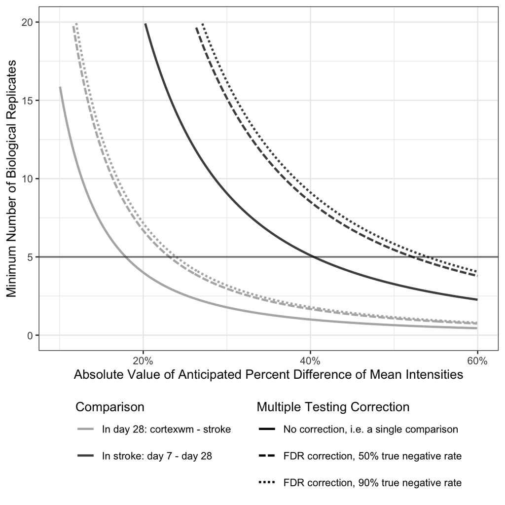

```r
greys <- setNames(c("grey70", "grey30"), c(lab_h2, lab_h1))  # within light / between dark

ggplot(df_curves, aes(x = pct, y = numSample, color = comparison)) +
  geom_line(aes(linetype = n_sig_test), linewidth = 0.9) +
  geom_hline(yintercept = 5, alpha = 0.5, linewidth = 0.7) +   # study replication
  scale_linetype_manual(values = c("solid", "31", "11"),
                        name = "Multiple Testing Correction") +
  scale_color_manual(values = greys) +
  scale_x_continuous(labels = scales::percent_format(accuracy = 1),
                     limits = c(0.1, 0.60)) +
  ylim(0, 20) +
  labs(x = "Absolute Value of Anticipated Percent Difference of Mean Intensities",
       y = "Minimum Number of Biological Replicates",
       color = "Comparison") +
  theme_bw() +
  theme(legend.position = "bottom") +
  guides(color    = guide_legend(order = 1, nrow = 2,
                                 theme = theme(legend.title.position = "top")),
         linetype = guide_legend(order = 2, nrow = 3,
                                 theme = theme(legend.title.position = "top")))
```

```r
ggsave(file.path("Recreated-Figures", "Figure-Stroke-Power.png"),
       height = 6, width = 6, units = "in")
```

Finally, at 5 biological replicates, what is the estimated minimum detectable difference?

```r
df_curves |>
  filter(n_sig_test == "FDR correction, 90% true negative rate") |>
  group_by(comparison) |>
  filter(abs(numSample - 5) == min(abs(numSample - 5))) |>
  mutate(Percent_Change = pct * 100) |>
  knitr::kable()
```

| delta | numSample | FDR | power | contrast | n_sig_test | ref | pct | comparison | Percent_Change |
| --- | --- | --- | --- | --- | --- | --- | --- | --- | --- |
| 221 | 5.021486 | 0.05 | 0.9 | In stroke: day 7 - day 28 | FDR correction, 90% true negative rate | 410.0957 | 0.5388987 | In stroke: day 7 - day 28 | 53.88987 |
| 210 | 4.984325 | 0.05 | 0.9 | In day 28: cortexwm - stroke | FDR correction, 90% true negative rate | 876.0299 | 0.2397179 | In day 28: cortexwm - stroke | 23.97179 |